# test_11282017_olina

```r
library(tidyverse)
```

```r
library(ggplot2)
library(gridExtra)
library(stringr)
library(dplyr)
library(data.table)
```

1. make a function. User will specify the dataframe and column. Function will return statistical summary as mean, median, and quartiles (1st, 2nd, 3rd)

```r
#x is the dataframe, y is the column
calculate_stat_summary <- function(x, y) {
  mean <- mean(x[[y]], na.rm = T)
  median <- median(x[[y]], na.rm = T)
  qua <- quantile(x[[y]], na.rm = T)
  tibble(Mean = mean, Median = median, "1st quartile" = qua[2],
         "2nd quartile" = qua[3],"3rd quartile" = qua[4]
         )
}
```

- Give three example of use

```r
#example
calculate_stat_summary(mtcars, "cyl")
```

```
## # A tibble: 1 x 5
##     Mean Median `1st quartile` `2nd quartile` `3rd quartile`
##    <dbl>  <dbl>          <dbl>          <dbl>          <dbl>
## 1 6.1875      6              4              6              8
```

```r
calculate_stat_summary(diamonds, "carat")
```

```
## # A tibble: 1 x 5
##        Mean Median `1st quartile` `2nd quartile` `3rd quartile`
##       <dbl>  <dbl>          <dbl>          <dbl>          <dbl>
## 1 0.7979397    0.7            0.4            0.7           1.04
```

```r
calculate_stat_summary(mpg, "displ")
```

```
## # A tibble: 1 x 5
##       Mean Median `1st quartile` `2nd quartile` `3rd quartile`
##      <dbl>  <dbl>          <dbl>          <dbl>          <dbl>
## 1 3.471795    3.3            2.4            3.3            4.6
```

2. make a function. User will specify the data frame and column to be plotted. Function plots histogram and boxplot side by side for numerical values. IF columns will happen to be categorical, no plot returned. Warning is given to user Funcion itself returns an orginal dataframe (to be used in chaining with dplyr)

```r
#x is the dataframe, y is the column
plot_column <- function(x, y) {
  if(typeof(x[[y]]) == "double"||typeof(x[[y]]) == "integer"){
    t1 <- ggplot(x, aes(x = x[[y]])) +
  geom_histogram() +
    xlab(y)
t2 <- ggplot(x, aes(x="", y = x[[y]])) +
  geom_boxplot() +
    ylab(y)
grid.arrange(t1,t2,ncol=2)

x
  }
  else{
    warning("The column selected for plot_column() function is categorical!!")
    x
  }
}
```

- Give 3 examples of use (including examples with chaining)

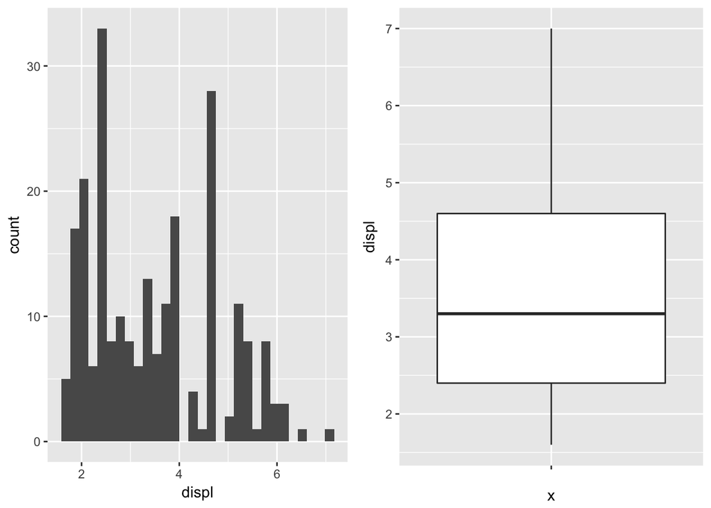

```
## # A tibble: 234 x 1
##     year
##    <int>
##  1  1999
##  2  1999
##  3  2008
##  4  2008
##  5  1999
##  6  1999
##  7  2008
##  8  1999
##  9  1999
## 10  2008
## # ... with 224 more rows
```

```r
#example of numerical column (double)
plot_column(mpg, "displ") %>%
  select(year)
```

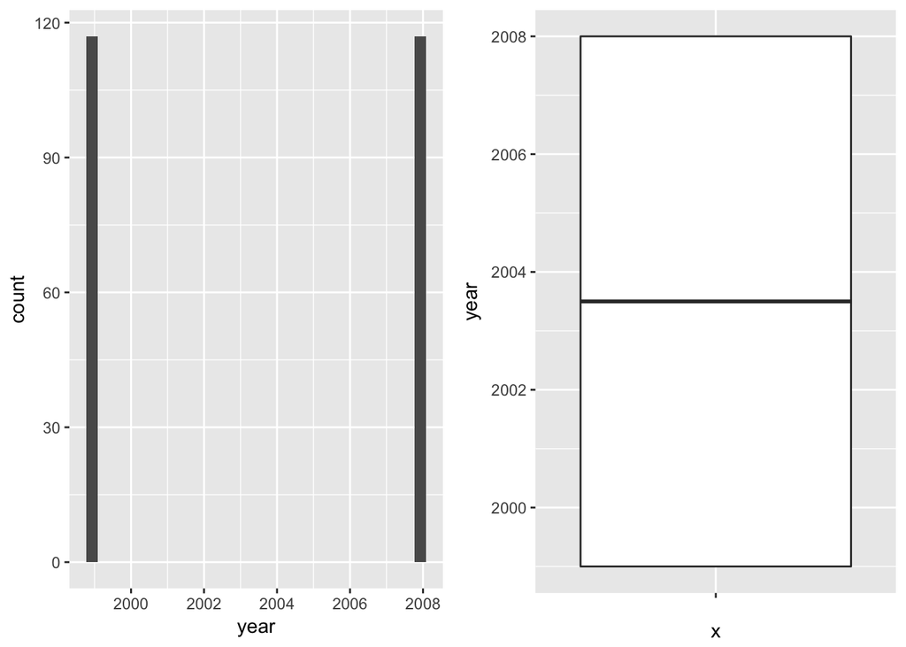

```
## # A tibble: 234 x 11
##    manufacturer      model displ  year   cyl      trans   drv   cty   hwy
##           <chr>      <chr> <dbl> <int> <int>      <chr> <chr> <int> <int>
##  1         audi         a4   1.8  1999     4   auto(l5)     f    18    29
##  2         audi         a4   1.8  1999     4 manual(m5)     f    21    29
##  3         audi         a4   2.0  2008     4 manual(m6)     f    20    31
##  4         audi         a4   2.0  2008     4   auto(av)     f    21    30
##  5         audi         a4   2.8  1999     6   auto(l5)     f    16    26
##  6         audi         a4   2.8  1999     6 manual(m5)     f    18    26
##  7         audi         a4   3.1  2008     6   auto(av)     f    18    27
##  8         audi a4 quattro   1.8  1999     4 manual(m5)     4    18    26
##  9         audi a4 quattro   1.8  1999     4   auto(l5)     4    16    25
## 10         audi a4 quattro   2.0  2008     4 manual(m6)     4    20    28
## # ... with 224 more rows, and 2 more variables: fl <chr>, class <chr>
```

```r
#example of numerical column (int)
plot_column(mpg, "year")
```

```r
#example of categorical column
plot_column(mpg, "trans") %>%
  select(year)
```

```
## # A tibble: 234 x 1
##     year
##    <int>
##  1  1999
##  2  1999
##  3  2008
##  4  2008
##  5  1999
##  6  1999
##  7  2008
##  8  1999
##  9  1999
## 10  2008
## # ... with 224 more rows
```

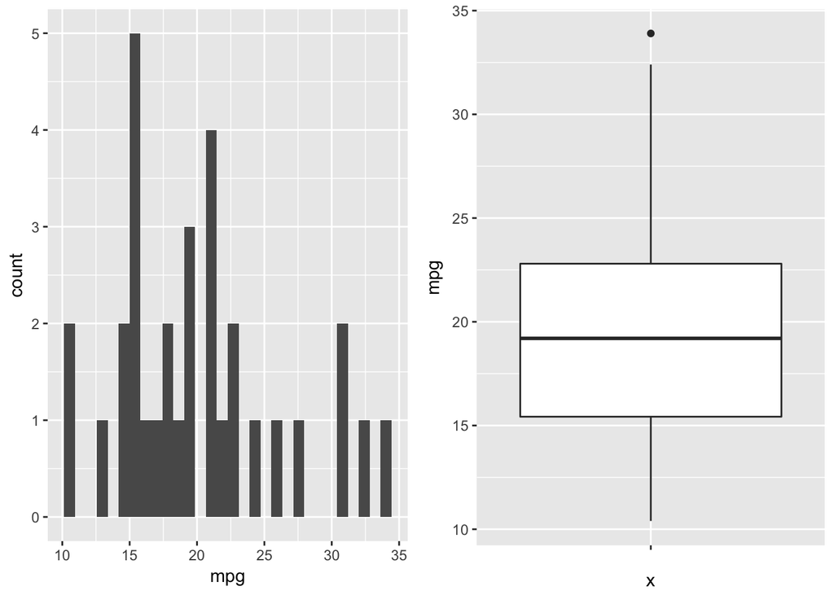

```
##    mpg cyl  disp  hp drat    wt  qsec vs am gear carb
## 1 21.0   6 160.0 110 3.90 2.620 16.46  0  1    4    4
## 2 21.0   6 160.0 110 3.90 2.875 17.02  0  1    4    4
## 3 21.4   6 258.0 110 3.08 3.215 19.44  1  0    3    1
## 4 18.1   6 225.0 105 2.76 3.460 20.22  1  0    3    1
## 5 19.2   6 167.6 123 3.92 3.440 18.30  1  0    4    4
## 6 17.8   6 167.6 123 3.92 3.440 18.90  1  0    4    4
## 7 19.7   6 145.0 175 3.62 2.770 15.50  0  1    5    6
```

```r
#example from another data table
plot_column(mtcars, "mpg") %>%
  filter(cyl == 6)
```

3. Make a function. User specifies data frame, name for new column, formula for calculation of new column (as a string). Please use dplyr to create new column. In order to do this you will have to use the following syntax dataframe %>% mutate(rlang::UQ(rlang::sym(new_col) := …) For … you need to combine two funcitons: parse and evaluate. parse(text =“string”) will get formula and turn it into an expression. eval will evaluate the expression A lot of info here https://cran.r-project.org/web/packages/dplyr/vignettes/programming.html

Too many things don’t work when I try using those ↑…

```r
calc_customized_func <- function(x, y, ...) {
  df <- x %>%
  mutate(...)
  colnames(df)[ncol(df)] <- y
  df
}
```

```r
calc_customized_func (mtcars, "hp_wt", hp/wt) #calculate horsepower per weight
```

```
##     mpg cyl  disp  hp drat    wt  qsec vs am gear carb    hp_wt
## 1  21.0   6 160.0 110 3.90 2.620 16.46  0  1    4    4 41.98473
## 2  21.0   6 160.0 110 3.90 2.875 17.02  0  1    4    4 38.26087
## 3  22.8   4 108.0  93 3.85 2.320 18.61  1  1    4    1 40.08621
## 4  21.4   6 258.0 110 3.08 3.215 19.44  1  0    3    1 34.21462
## 5  18.7   8 360.0 175 3.15 3.440 17.02  0  0    3    2 50.87209
## 6  18.1   6 225.0 105 2.76 3.460 20.22  1  0    3    1 30.34682
## 7  14.3   8 360.0 245 3.21 3.570 15.84  0  0    3    4 68.62745
## 8  24.4   4 146.7  62 3.69 3.190 20.00  1  0    4    2 19.43574
## 9  22.8   4 140.8  95 3.92 3.150 22.90  1  0    4    2 30.15873
## 10 19.2   6 167.6 123 3.92 3.440 18.30  1  0    4    4 35.75581
## 11 17.8   6 167.6 123 3.92 3.440 18.90  1  0    4    4 35.75581
## 12 16.4   8 275.8 180 3.07 4.070 17.40  0  0    3    3 44.22604
## 13 17.3   8 275.8 180 3.07 3.730 17.60  0  0    3    3 48.25737
## 14 15.2   8 275.8 180 3.07 3.780 18.00  0  0    3    3 47.61905
```

[output cut: 18 more lines]

```r
calc_customized_func (diamonds, "Endings", price %% 10) #get last digit of price
```

```
## # A tibble: 53,940 x 11
##    carat       cut color clarity depth table price     x     y     z
##    <dbl>     <ord> <ord>   <ord> <dbl> <dbl> <int> <dbl> <dbl> <dbl>
##  1  0.23     Ideal     E     SI2  61.5    55   326  3.95  3.98  2.43
##  2  0.21   Premium     E     SI1  59.8    61   326  3.89  3.84  2.31
##  3  0.23      Good     E     VS1  56.9    65   327  4.05  4.07  2.31
##  4  0.29   Premium     I     VS2  62.4    58   334  4.20  4.23  2.63
##  5  0.31      Good     J     SI2  63.3    58   335  4.34  4.35  2.75
##  6  0.24 Very Good     J    VVS2  62.8    57   336  3.94  3.96  2.48
##  7  0.24 Very Good     I    VVS1  62.3    57   336  3.95  3.98  2.47
##  8  0.26 Very Good     H     SI1  61.9    55   337  4.07  4.11  2.53
##  9  0.22      Fair     E     VS2  65.1    61   337  3.87  3.78  2.49
## 10  0.23 Very Good     H     VS1  59.4    61   338  4.00  4.05  2.39
## # ... with 53,930 more rows, and 1 more variables: Endings <dbl>
```